# The_Analytics_Edge_edX_MIT15.071x_June2015

### Assignment 2: STATE DATA (OPTIONAL)

We often take data for granted. However, one of the hardest parts about analyzing a problem you’re interested in can be to find good data to answer the questions you want to ask. As you’re learning R, though, there are many datasets that R has built in that you can take advantage of.

In this problem, we will be examining the “state” dataset, which has data from the 1970s on all fifty US states. For each state, the dataset includes the population, per capita income, illiteracy rate, murder rate, high school graduation rate, average number of frost days, area, latitude and longitude, division the state belongs to, region the state belongs to, and two-letter abbreviation.

```r
#lets load the data set
data(state) #inbuilt data set containing 6 vectors and 1 data frame(state.x77).Lets combine them to a single data frame
statedata = cbind(data.frame(state.x77), state.abb, state.area, state.center,  state.division, state.name, state.region)  # or import statedata.csv
str(statedata)
```

```
## 'data.frame':    50 obs. of  15 variables:
##  $ Population    : num  3615 365 2212 2110 21198 ...
##  $ Income        : num  3624 6315 4530 3378 5114 ...
##  $ Illiteracy    : num  2.1 1.5 1.8 1.9 1.1 0.7 1.1 0.9 1.3 2 ...
##  $ Life.Exp      : num  69 69.3 70.5 70.7 71.7 ...
##  $ Murder        : num  15.1 11.3 7.8 10.1 10.3 6.8 3.1 6.2 10.7 13.9 ...
##  $ HS.Grad       : num  41.3 66.7 58.1 39.9 62.6 63.9 56 54.6 52.6 40.6 ...
##  $ Frost         : num  20 152 15 65 20 166 139 103 11 60 ...
##  $ Area          : num  50708 566432 113417 51945 156361 ...
##  $ state.abb     : Factor w/ 50 levels "AK","AL","AR",..: 2 1 4 3 5 6 7 8 9 10 ...
##  $ state.area    : num  51609 589757 113909 53104 158693 ...
##  $ x             : num  -86.8 -127.2 -111.6 -92.3 -119.8 ...
##  $ y             : num  32.6 49.2 34.2 34.7 36.5 ...
##  $ state.division: Factor w/ 9 levels "New England",..: 4 9 8 5 9 8 1 3 3 3 ...
##  $ state.name    : Factor w/ 50 levels "Alabama","Alaska",..: 1 2 3 4 5 6 7 8 9 10 ...
##  $ state.region  : Factor w/ 4 levels "Northeast","South",..: 2 4 4 2 4 4 1 2 2 2 ...
```

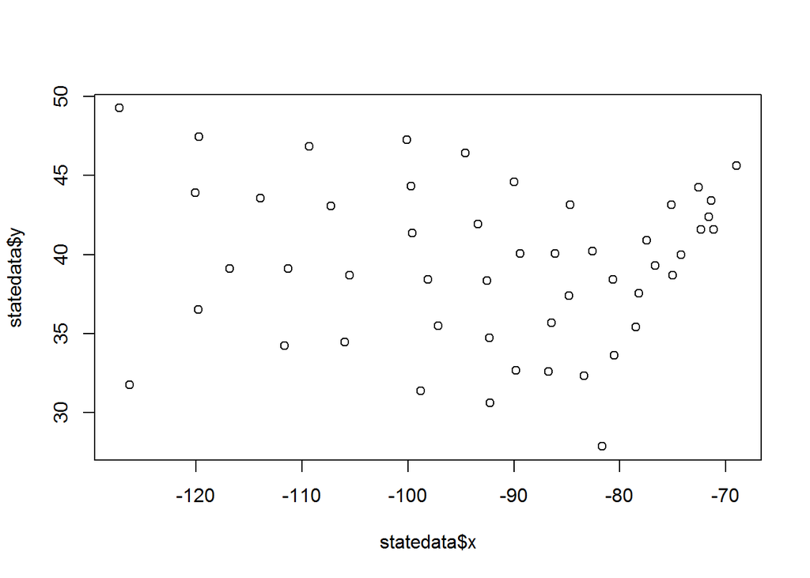

```r
#PROBLEM 1.1 - DATA EXPLORATION

#We begin by exploring the data. Plot all of the states' centers with latitude on the y axis (the "y" variable in our dataset) and longitude on the x axis (the "x" variable in our dataset). The shape of the plot should look like the outline of the United States! Note that Alaska and Hawaii have had their coordinates adjusted to appear just off of the west coast.
plot(statedata$x,statedata$y)
```

```r
#In the R command you used to generate this plot, which variable name did you use as the first argument?
#Ans:

####################################

#PROBLEM 1.2 - DATA EXPLORATION

#Using the tapply command, determine which region of the US (West, North Central, South, or Northeast) has the highest average high school graduation rate of all the states in the region:
tapply(statedata$HS.Grad,statedata$state.region,mean)
```

```
##     Northeast         South North Central          West
##      53.96667      44.34375      54.51667      62.00000
```

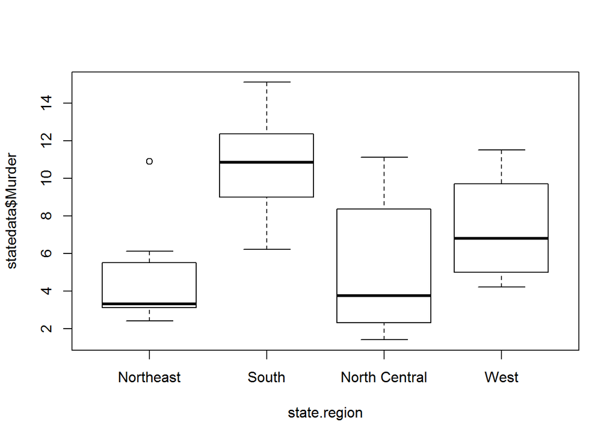

```r
#Ans:West

########################

#PROBLEM 1.3 - DATA EXPLORATION

#Now, make a boxplot of the murder rate by region (for more information about creating boxplots in R, type ?boxplot in your console).
plot(statedata$Murder~state.region) #or boxplot(statedata$Murder ~ statedata$state.region)
```

```r
#Which region has the highest median murder rate?
#Ans:South

#########################

#PROBLEM 1.4 - DATA EXPLORATION

#You should see that there is an outlier in the Northeast region of the boxplot you just generated. Which state does this correspond to? (Hint: There are many ways to find the answer to this question, but one way is to use the subset command to only look at the Northeast data.)
NE<-subset(statedata,statedata$state.region=="Northeast")
NE$state.name[NE$Murder==max(NE$Murder)]
```

```
## [1] New York
## 50 Levels: Alabama Alaska Arizona Arkansas California ... Wyoming
```

```r
#Ans:New York

#################################

#PROBLEM 2.1 - PREDICTING LIFE EXPECTANCY - AN INITIAL MODEL

#We would like to build a model to predict life expectancy by state using the state statistics we have in our dataset.

#Build the model with all potential variables included (Population, Income, Illiteracy, Murder, HS.Grad, Frost, and Area). Note that you should use the variable "Area" in your model, NOT the variable "state.area".
LinReg<-lm(Life.Exp~Population+Income+Illiteracy+Murder+HS.Grad+Frost+Area,data=statedata)
summary(LinReg)
```

```
##
## Call:
## lm(formula = Life.Exp ~ Population + Income + Illiteracy + Murder +
##     HS.Grad + Frost + Area, data = statedata)
##
## Residuals:
##      Min       1Q   Median       3Q      Max
## -1.48895 -0.51232 -0.02747  0.57002  1.49447
##
## Coefficients:
##               Estimate Std. Error t value Pr(>|t|)
## (Intercept)  7.094e+01  1.748e+00  40.586  < 2e-16 ***
## Population   5.180e-05  2.919e-05   1.775   0.0832 .
## Income      -2.180e-05  2.444e-04  -0.089   0.9293
## Illiteracy   3.382e-02  3.663e-01   0.092   0.9269
## Murder      -3.011e-01  4.662e-02  -6.459 8.68e-08 ***
## HS.Grad      4.893e-02  2.332e-02   2.098   0.0420 *
## Frost       -5.735e-03  3.143e-03  -1.825   0.0752 .
## Area        -7.383e-08  1.668e-06  -0.044   0.9649
## ---
## Signif. codes:  0 '***' 0.001 '**' 0.01 '*' 0.05 '.' 0.1 ' ' 1
##
## Residual standard error: 0.7448 on 42 degrees of freedom
## Multiple R-squared:  0.7362, Adjusted R-squared:  0.6922
## F-statistic: 16.74 on 7 and 42 DF,  p-value: 2.534e-10
```

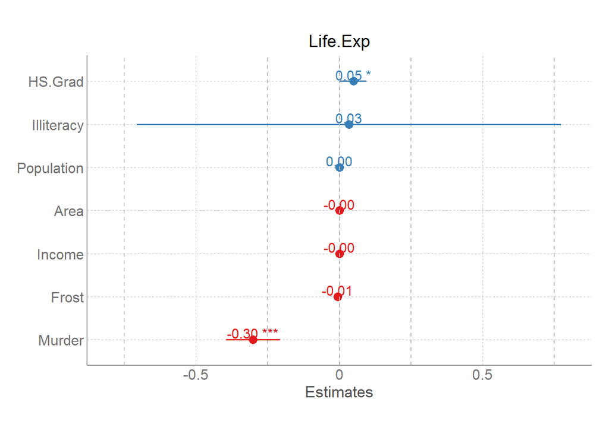

```r
#lets plot the coeff using sjPlot library
library(sjPlot)
#?sjp.lm
sjp.lm(LinReg,type="lm")
```

```r
#What is the coefficient for "Income" in your linear regression model?
coef(summary(LinReg))["Income","Estimate"]  #or look in summary(LinReg)
```

```
## [1] -2.180424e-05
```

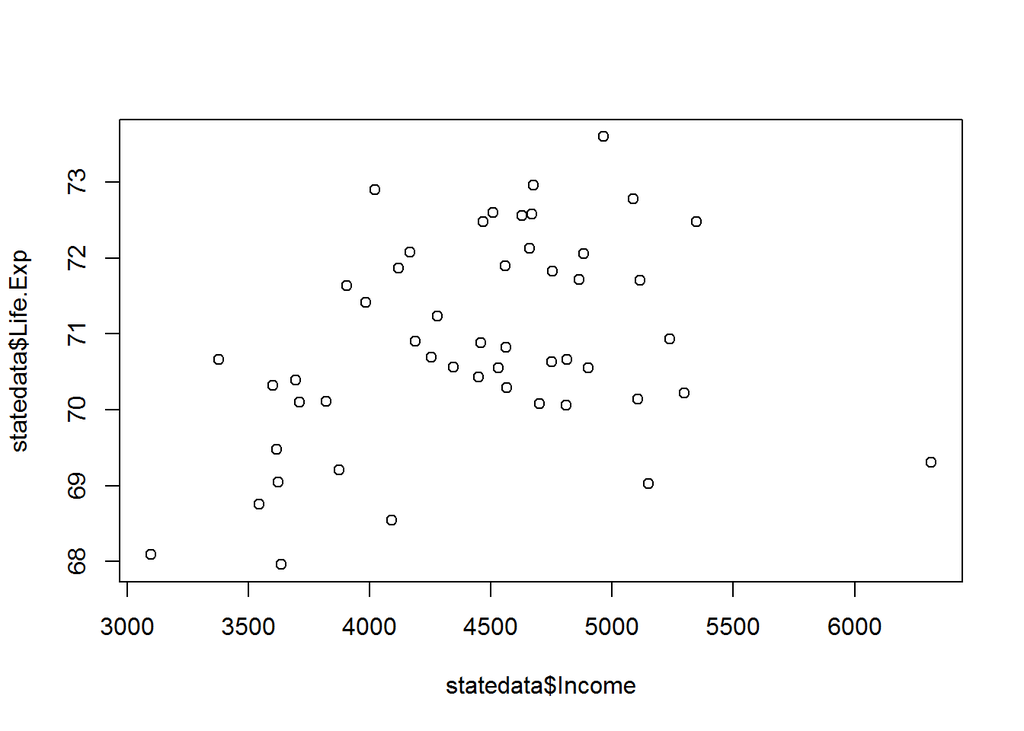

```r
#Ans:-2.180424e-05  (or -0.0000218)

#########################################

#PROBLEM 2.2 - PREDICTING LIFE EXPECTANCY - AN INITIAL MODEL

#Call the coefficient for income x (the answer to Problem 2.1). What is the interpretation of the coefficient x?
#Ans:For a one unit increase in income, predicted life expectancy decreases by |x|
#EXPLANATION:If we increase income by one unit, then our model's prediction will increase by the coefficient of income, x. Because x is negative, this is the same as predicted life expectancy decreasing by |x|.

#######################################

#PROBLEM 2.3 - PREDICTING LIFE EXPECTANCY - AN INITIAL MODEL

#Now plot a graph of life expectancy vs. income using the command:
plot(statedata$Income, statedata$Life.Exp)
```